# Machine Learning for Biological Data

Mauricio Izquierdo

2025-02-26

# Parte 1: Reducción de dimensiones con Aprendizaje no supervisado

## Carga y procesamiento de los datos

En primer lugar, cargamos el conjunto de datos facilitados para la realización del ejercicio “heart_failure_clinical_records_dataset.csv” y realizamos un analisis exploratorio de los mismos para comprenderlos y saber a que nos enfrentamos.

```r
# Establecer el directorio de trabajo
setwd("C:/Users/Mauricio Izquierdo/Desktop/Master_Bioinformática/Primer cuatri/IA/Modelos")

# Cargar librerías necesarias
library(tidyverse)
library(factoextra)
```

```r
library(ggplot2)

# Cargar los datos
data <- read.csv("heart_failure_clinical_records_dataset.csv")

# Explorar los datos
# Dimensiones y estructura
dim(data)
```

```
## [1] 299  13
```

```r
str(data)
```

```
## 'data.frame':    299 obs. of  13 variables:
##  $ age                     : num  75 55 65 50 65 90 75 60 65 80 ...
##  $ anaemia                 : int  0 0 0 1 1 1 1 1 0 1 ...
##  $ creatinine_phosphokinase: int  582 7861 146 111 160 47 246 315 157 123 ...
##  $ diabetes                : int  0 0 0 0 1 0 0 1 0 0 ...
##  $ ejection_fraction       : int  20 38 20 20 20 40 15 60 65 35 ...
##  $ high_blood_pressure     : int  1 0 0 0 0 1 0 0 0 1 ...
##  $ platelets               : num  265000 263358 162000 210000 327000 ...
##  $ serum_creatinine        : num  1.9 1.1 1.3 1.9 2.7 2.1 1.2 1.1 1.5 9.4 ...
##  $ serum_sodium            : int  130 136 129 137 116 132 137 131 138 133 ...
##  $ sex                     : int  1 1 1 1 0 1 1 1 0 1 ...
##  $ smoking                 : int  0 0 1 0 0 1 0 1 0 1 ...
##  $ time                    : int  4 6 7 7 8 8 10 10 10 10 ...
##  $ DEATH_EVENT             : int  1 1 1 1 1 1 1 1 1 1 ...
```

```r
# Ver primeras filas
head(data)
```

|  | age | anaemia | creatinine_phosphokinase | diabetes | ejection_fraction | high_blood_pressure | platelets | serum_creatinine | serum_sodium | sex | smoking | time | DEATH_EVENT |
| --- | --- | --- | --- | --- | --- | --- | --- | --- | --- | --- | --- | --- | --- |
| 1 | 75 | 0 | 582 | 0 | 20 | 1 | 265000 | 1.9 | 130 | 1 | 0 | 4 | 1 |
| 2 | 55 | 0 | 7861 | 0 | 38 | 0 | 263358 | 1.1 | 136 | 1 | 0 | 6 | 1 |
| 3 | 65 | 0 | 146 | 0 | 20 | 0 | 162000 | 1.3 | 129 | 1 | 1 | 7 | 1 |
| 4 | 50 | 1 | 111 | 0 | 20 | 0 | 210000 | 1.9 | 137 | 1 | 0 | 7 | 1 |
| 5 | 65 | 1 | 160 | 1 | 20 | 0 | 327000 | 2.7 | 116 | 0 | 0 | 8 | 1 |
| 6 | 90 | 1 | 47 | 0 | 40 | 1 | 204000 | 2.1 | 132 | 1 | 1 | 8 | 1 |

```r
# Resumen estadístico
summary(data)
```

```
##       age           anaemia       creatinine_phosphokinase    diabetes
##  Min.   :40.00   Min.   :0.0000   Min.   :  23.0           Min.   :0.0000
##  1st Qu.:51.00   1st Qu.:0.0000   1st Qu.: 116.5           1st Qu.:0.0000
##  Median :60.00   Median :0.0000   Median : 250.0           Median :0.0000
##  Mean   :60.83   Mean   :0.4314   Mean   : 581.8           Mean   :0.4181
##  3rd Qu.:70.00   3rd Qu.:1.0000   3rd Qu.: 582.0           3rd Qu.:1.0000
##  Max.   :95.00   Max.   :1.0000   Max.   :7861.0           Max.   :1.0000
##  ejection_fraction high_blood_pressure   platelets      serum_creatinine
##  Min.   :14.00     Min.   :0.0000      Min.   : 25100   Min.   :0.500
##  1st Qu.:30.00     1st Qu.:0.0000      1st Qu.:212500   1st Qu.:0.900
##  Median :38.00     Median :0.0000      Median :262000   Median :1.100
##  Mean   :38.08     Mean   :0.3512      Mean   :263358   Mean   :1.394
##  3rd Qu.:45.00     3rd Qu.:1.0000      3rd Qu.:303500   3rd Qu.:1.400
##  Max.   :80.00     Max.   :1.0000      Max.   :850000   Max.   :9.400
##   serum_sodium        sex            smoking            time
##  Min.   :113.0   Min.   :0.0000   Min.   :0.0000   Min.   :  4.0
##  1st Qu.:134.0   1st Qu.:0.0000   1st Qu.:0.0000   1st Qu.: 73.0
##  Median :137.0   Median :1.0000   Median :0.0000   Median :115.0
##  Mean   :136.6   Mean   :0.6488   Mean   :0.3211   Mean   :130.3
##  3rd Qu.:140.0   3rd Qu.:1.0000   3rd Qu.:1.0000   3rd Qu.:203.0
##  Max.   :148.0   Max.   :1.0000   Max.   :1.0000   Max.   :285.0
##   DEATH_EVENT
##  Min.   :0.0000
##  1st Qu.:0.0000
##  Median :0.0000
##  Mean   :0.3211
##  3rd Qu.:1.0000
##  Max.   :1.0000
```

```r
# Comprobar valores faltantes
colSums(is.na(data))
```

```
##                      age                  anaemia creatinine_phosphokinase
##                        0                        0                        0
##                 diabetes        ejection_fraction      high_blood_pressure
##                        0                        0                        0
##                platelets         serum_creatinine             serum_sodium
##                        0                        0                        0
##                      sex                  smoking                     time
##                        0                        0                        0
##              DEATH_EVENT
##                        0
```

De los resultados de dicho analisis exploratorio de los datos observamos como no hay ningun valor faltante que manejar en el data frame, asi como tambien observamos que la vaariable en estudio (segun lo expuesto en el documento Variables.docx) DEATH_EVENT se trata de un dato booleano con formato interger. Como posteriormente nos va a interesar predecir esta variable con el aprendizaje supervisado y reducir la dimensionalidad de los datos clasificandolos en funcion de la misma, convertimos la variable en factor para poder realizar estos procesos en los siguientes pasos del ejercicio.

Cabe destacar la interpretación de la misma como un dato booleano, donde “1” significa que SI hay fallo cardiaco mientras que “0” lo niega.

En lo relativo al analisis estadistico de los datos, al presentar el data frame tantas variables de tipo booleano, muchas de las estadisticas dadas no aportan una información que nos pueda resultar de utilidad, mas alla de si hay mas o menos valores afirmativos o negativos (fijandonos en el valor de la media).

```r
# Convertimos la variable Death_Event a factor para poder clasificar los
# datos en funcion a ella y poder trabajar con ello posteriormente
data$DEATH_EVENT <- as.factor(data$DEATH_EVENT)

# Verificamos la transformación
str(data)
```

```
## 'data.frame':    299 obs. of  13 variables:
##  $ age                     : num  75 55 65 50 65 90 75 60 65 80 ...
##  $ anaemia                 : int  0 0 0 1 1 1 1 1 0 1 ...
##  $ creatinine_phosphokinase: int  582 7861 146 111 160 47 246 315 157 123 ...
##  $ diabetes                : int  0 0 0 0 1 0 0 1 0 0 ...
##  $ ejection_fraction       : int  20 38 20 20 20 40 15 60 65 35 ...
##  $ high_blood_pressure     : int  1 0 0 0 0 1 0 0 0 1 ...
##  $ platelets               : num  265000 263358 162000 210000 327000 ...
##  $ serum_creatinine        : num  1.9 1.1 1.3 1.9 2.7 2.1 1.2 1.1 1.5 9.4 ...
##  $ serum_sodium            : int  130 136 129 137 116 132 137 131 138 133 ...
##  $ sex                     : int  1 1 1 1 0 1 1 1 0 1 ...
##  $ smoking                 : int  0 0 1 0 0 1 0 1 0 1 ...
##  $ time                    : int  4 6 7 7 8 8 10 10 10 10 ...
##  $ DEATH_EVENT             : Factor w/ 2 levels "0","1": 2 2 2 2 2 2 2 2 2 2 ...
```

Observamos que la variable DEATH_EVENT se ha convertido a tipo facctor corectamente.

Finalmente, para preparar el conjunto de datos para la realización dle PCA realizaremos una selección de aquellas variables de tipo numerico y las escalaremos para evitar que la interpretación de los datos se encuentre sesgada.

```r
# Extraer los datos numéricos del df de trabajo para el posterior PCA
data_numeric <- data %>% select(is.numeric)
# Verificamos la selección
str(data_numeric)
```

```
## 'data.frame':    299 obs. of  12 variables:
##  $ age                     : num  75 55 65 50 65 90 75 60 65 80 ...
##  $ anaemia                 : int  0 0 0 1 1 1 1 1 0 1 ...
##  $ creatinine_phosphokinase: int  582 7861 146 111 160 47 246 315 157 123 ...
##  $ diabetes                : int  0 0 0 0 1 0 0 1 0 0 ...
##  $ ejection_fraction       : int  20 38 20 20 20 40 15 60 65 35 ...
##  $ high_blood_pressure     : int  1 0 0 0 0 1 0 0 0 1 ...
##  $ platelets               : num  265000 263358 162000 210000 327000 ...
##  $ serum_creatinine        : num  1.9 1.1 1.3 1.9 2.7 2.1 1.2 1.1 1.5 9.4 ...
##  $ serum_sodium            : int  130 136 129 137 116 132 137 131 138 133 ...
##  $ sex                     : int  1 1 1 1 0 1 1 1 0 1 ...
##  $ smoking                 : int  0 0 1 0 0 1 0 1 0 1 ...
##  $ time                    : int  4 6 7 7 8 8 10 10 10 10 ...
```

```r
# Normalizamos los datos
scaled_data <- scale(data_numeric)
```

Observamos como se han seleccionado todas las variables a excepción de la variable DEATH_EVENT que convertimos a factor.

## Aprendizaje no supervisado - Aplicación del PCA

Reducimos las dimensiones del conjunto de datos aplicando un PCA.

```r
# Extraer la variable de DEATH_EVENT para la visualización
dethev_labels <- data$DEATH_EVENT

# Aplicamos el PCA
pca_result <- prcomp(scaled_data, center = TRUE, scale. = TRUE)
```

Separaremos la variable factor y la recogeremos en una variable nueva para facilitarnos el trabajo mas adelante. Tras ello graficamos la varianza explicada por cada componente resultante del PCA haciendo uso de la función fviz_eig, permitiendonos apoyarnos en dicha gráfica para buscar el ‘códo’ que nos determina el número óptimo de componentes principales con las que continuar el análisis.

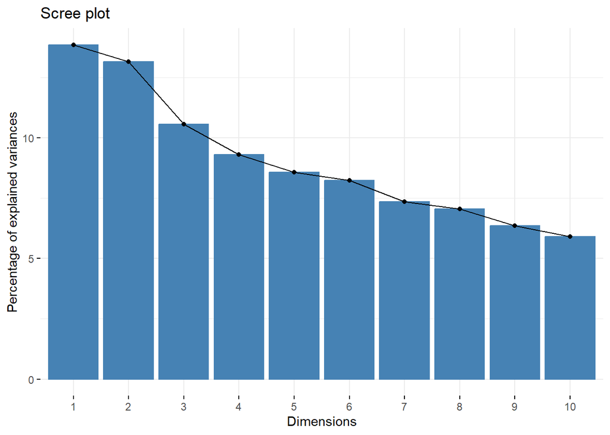

```r
# Elegir número adecuado de componentes principales
# Para ello nos apoyamos en la gráfica dada por fviz_eig buscando el 'codo'
fviz_eig(pca_result)
```

```r
        # Vemos un pequeño codo tras la 2ª componente, por lo que
        # consideramos 2 componentes principales como el numero óptimo de componentes de trabajo
```

Tras la segunda componente vemos una disminución mas o menos considerable en la varianza explicada por la tercera componente y tras esta, las variaciones son menores, por lo que consideramos 2 componentes prncipales como el número de trabajo óptimo durante el resto del análisis.

### Visualización de los datos

Pasamos directamente a visualizar el conjunto de menor dimensión seleccionado haciendo uso de un gráfico de dispersión con ggplot2 y agrupando por el valor positivo o negatiov de la variable Death_Event.

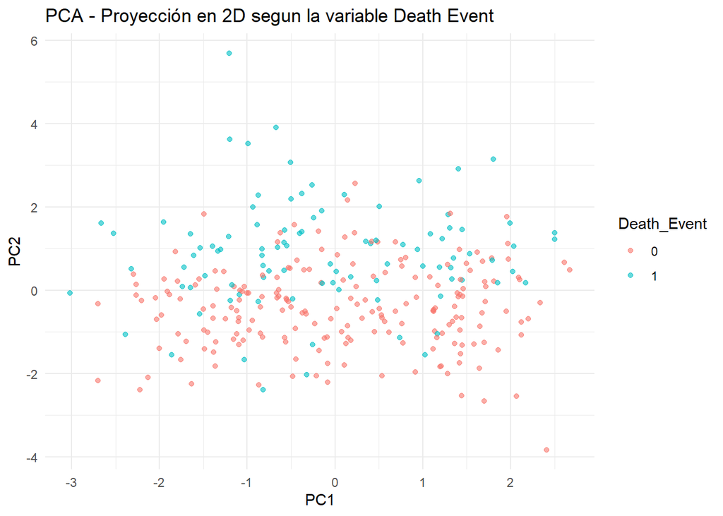

```r
# Extraer coordenadas de los individuos
pca_def <- as.data.frame(pca_result$x)
pca_def$Death_Event <- as.factor(dethev_labels)

# Visualización en espacio reducido con ggplot2, coloreando por 'clase'
# En este caso 'clase' = 'Death_Event'
pca_plot <- ggplot(pca_def, aes(x = PC1, y = PC2, color = Death_Event)) +
  geom_point(alpha = 0.6) +
  labs(title = "PCA - Proyección en 2D segun la variable Death Event", x = "PC1", y = "PC2") +
  theme_minimal()

pca_plot
```

```r
        # No se observa una agrupación o tendencia clara entre estos y los datos de trabajo
```

# Parte 2: Predicción con aprendizaje supervisado

Partiremos del conjunto de datos reducido del apartado annterior. a partir del mismo, preparamos el conjunto de datos para aplicar algoritmos de aprendizaje supervisado dividiendolo en el conjunto dde entrenamiento y prueba.

```r
# Cargar librerías necesarias para los modelos de aprendizaje supervisado
library(caret)
library(randomForest)
library(class)

# Seleccionar solo las dos primeras componentes principales y la variable Death_Event
pca_def_reduced <- pca_def[, c("PC1", "PC2", "Death_Event")]

# Dividir en conjunto de entrenamiento y prueba (70%-30%)
set.seed(007)  # Para reproducibilidad
train_index <- createDataPartition(pca_def_reduced$Death_Event, p = 0.7, list = FALSE)
train_data <- pca_def_reduced[train_index, ]
test_data <- pca_def_reduced[-train_index, ]
```

Tras ello, aplicaremos 3 algoritmos de aprendizaje supervisado para compararlos y poder elegir aquel que responde mejor al conjunto de datos. Usaremos la Regresión logística (util al ser una variable booleana), el Random forest y KNN.

## Regresión logística

```r
log_model <- glm(Death_Event ~ ., data = train_data, family = binomial)

# Predicción en conjunto de prueba
log_preds <- predict(log_model, newdata = test_data, type = "response")
log_preds_deathev <- ifelse(log_preds > 0.5, 1, 0)  # Convertir probabilidades en clases

# Evaluación del modelo
conf_matrix_log <- confusionMatrix(factor(log_preds_deathev), factor(test_data$Death_Event))
print(conf_matrix_log)
```

```
## Confusion Matrix and Statistics
##
##           Reference
## Prediction  0  1
##          0 49 12
##          1 11 16
##
##                Accuracy : 0.7386
##                  95% CI : (0.6341, 0.8266)
##     No Information Rate : 0.6818
##     P-Value [Acc > NIR] : 0.1512
##
##                   Kappa : 0.3918
##
##  Mcnemar's Test P-Value : 1.0000
##
##             Sensitivity : 0.8167
##             Specificity : 0.5714
##          Pos Pred Value : 0.8033
##          Neg Pred Value : 0.5926
##              Prevalence : 0.6818
##          Detection Rate : 0.5568
##    Detection Prevalence : 0.6932
##       Balanced Accuracy : 0.6940
##
##        'Positive' Class : 0
##
```

## Random Forest

```r
rf_model <- randomForest(Death_Event ~ ., data = train_data, ntree = 100, importance = TRUE)

# Predicción en conjunto de prueba
rf_preds <- predict(rf_model, newdata = test_data)

# Evaluación del modelo
conf_matrix_rf <- confusionMatrix(factor(rf_preds), factor(test_data$Death_Event))
print(conf_matrix_rf)
```

```
## Confusion Matrix and Statistics
##
##           Reference
## Prediction  0  1
##          0 46 14
##          1 14 14
##
##                Accuracy : 0.6818
##                  95% CI : (0.5739, 0.7771)
##     No Information Rate : 0.6818
##     P-Value [Acc > NIR] : 0.551
##
##                   Kappa : 0.2667
##
##  Mcnemar's Test P-Value : 1.000
##
##             Sensitivity : 0.7667
##             Specificity : 0.5000
##          Pos Pred Value : 0.7667
##          Neg Pred Value : 0.5000
##              Prevalence : 0.6818
##          Detection Rate : 0.5227
##    Detection Prevalence : 0.6818
##       Balanced Accuracy : 0.6333
##
##        'Positive' Class : 0
##
```

## K - Nearest Neighbors (KNN)

```r
# Ajustamos el número de vecinos (k). Probamos con  k = 2, 3, 4 y 5.
# Tras esto, bservamos como el 'k' óptimo es k = 4.
k_value <- 4

# Entrenamos el modelo KNN (k = 2)
knn_preds <- knn(train = train_data[, c("PC1", "PC2")], test = test_data[, c("PC1", "PC2")], cl = train_data$Death_Event, k = k_value)

# Evaluación del modelo KNN
conf_matrix_knn <- confusionMatrix(factor(knn_preds), factor(test_data$Death_Event))
print(conf_matrix_knn)
```

```
## Confusion Matrix and Statistics
##
##           Reference
## Prediction  0  1
##          0 47 13
##          1 13 15
##
##                Accuracy : 0.7045
##                  95% CI : (0.5978, 0.7971)
##     No Information Rate : 0.6818
##     P-Value [Acc > NIR] : 0.3705
##
##                   Kappa : 0.319
##
##  Mcnemar's Test P-Value : 1.0000
##
##             Sensitivity : 0.7833
##             Specificity : 0.5357
##          Pos Pred Value : 0.7833
##          Neg Pred Value : 0.5357
##              Prevalence : 0.6818
##          Detection Rate : 0.5341
##    Detection Prevalence : 0.6818
##       Balanced Accuracy : 0.6595
##
##        'Positive' Class : 0
##
```

### Evaluación del modelo

Tras aplicar los 3 algoritmos de aprendizaje supervisado sobre los datos, observamos las respectivas matrices de confusión que recojen las medidas que nos permiten contrastar el rendimiento de los modelos. Para facilitar la lectura e interpretación de las mismas nos fijaremos en la precisión (accuracy), Recall y F1-score de las 3 matrices de confusión.

Para ello, en primer lugar recogeremos y mostraremos unicamente las metricas de rendimiento de estas matrices.

```r
# Extraer métricas de rendimiento
metrics_log <- conf_matrix_log$byClass
metrics_rf <- conf_matrix_rf$byClass
metrics_knn <- conf_matrix_knn$byClass

# Mostrar las métricas de rendimiento
print("Métricas de Regresión Logística")
```

```
## [1] "Métricas de Regresión Logística"
```

```r
print(metrics_log)
```

```
##          Sensitivity          Specificity       Pos Pred Value
##            0.8166667            0.5714286            0.8032787
##       Neg Pred Value            Precision               Recall
##            0.5925926            0.8032787            0.8166667
##                   F1           Prevalence       Detection Rate
##            0.8099174            0.6818182            0.5568182
## Detection Prevalence    Balanced Accuracy
##            0.6931818            0.6940476
```

```r
print("Métricas de Random Forest")
```

```
## [1] "Métricas de Random Forest"
```

```r
print(metrics_rf)
```

```
##          Sensitivity          Specificity       Pos Pred Value
##            0.7666667            0.5000000            0.7666667
##       Neg Pred Value            Precision               Recall
##            0.5000000            0.7666667            0.7666667
##                   F1           Prevalence       Detection Rate
##            0.7666667            0.6818182            0.5227273
## Detection Prevalence    Balanced Accuracy
##            0.6818182            0.6333333
```

```r
print("Métricas de KNN")
```

```
## [1] "Métricas de KNN"
```

```r
print(metrics_knn)
```

```
##          Sensitivity          Specificity       Pos Pred Value
##            0.7833333            0.5357143            0.7833333
##       Neg Pred Value            Precision               Recall
##            0.5357143            0.7833333            0.7833333
##                   F1           Prevalence       Detection Rate
##            0.7833333            0.6818182            0.5340909
## Detection Prevalence    Balanced Accuracy
##            0.6818182            0.6595238
```

Posteriormente, nos centraremos en la precisión, recall y F1-score para interprretar y evluar el rendimiento de los 3 modelos de una forma intercomparativa.

```r
# Comparar precisión, recall y F1-score
#Regresión logística
accuracy_log <- conf_matrix_log$overall['Accuracy']
recall_log <- metrics_log['Recall']
f1_log <- metrics_log['F1']

# Random Forest
accuracy_rf <- conf_matrix_rf$overall['Accuracy']
recall_rf <- metrics_rf['Recall']
f1_rf <- metrics_rf['F1']

# K-Nearest Neighbors
accuracy_knn <- conf_matrix_knn$overall['Accuracy']
recall_knn <- metrics_knn['Recall']
f1_knn <- metrics_knn['F1']

# Mostrar comparación
cat("Regresión Logística:\n - Accuracy:", accuracy_log, "\n - Recall:", recall_log, "\n - F1:", f1_log, "\n\n")
```

```
## Regresión Logística:
##  - Accuracy: 0.7386364
##  - Recall: 0.8166667
##  - F1: 0.8099174
```

```r
cat("Random Forest:\n - Accuracy:", accuracy_rf, "\n - Recall:", recall_rf, "\n - F1:", f1_rf, "\n\n")
```

```
## Random Forest:
##  - Accuracy: 0.6818182
##  - Recall: 0.7666667
##  - F1: 0.7666667
```

```r
cat("KNN:\n - Accuracy:", accuracy_knn, "\n - Recall:", recall_knn, "\n - F1:", f1_knn, "\n\n")
```

```
## KNN:
##  - Accuracy: 0.7045455
##  - Recall: 0.7833333
##  - F1: 0.7833333
```

En este caso, observamos como el modelo de regresión logística presenta una precisión, recall y F1-score superiores a los otros dos modelos, por lo que se tratará del modelo mas adecuado entre los 3 a utilizar. Con la medida de la precisón observamos una idea global de como esta funcionando el modelo, ya que se trata de la proporcion de predicciones correctas de las realizadas por el mismo. Ademas al tener un recall o sensibilidad mayor tambien nos esta indicando que la proporción de verdaderos positivos es mas alta. Ademas, el F1-score nos da una idea global, equilibrando la precisión y la sensibilidad, que en casos muy dudosos nos permite comparar con mayor facilidad entre modelos. En este caso tambien se trata del mayor valor por lo que las 3 medidas nos estan indicando que el modelo de regresión logística es el que mejor se adecua a los datos empleados.